# Assessment-Urban Analytics and City Science

```r
  ### OLS regression model
ZAF_migration_flows_and <- ZAF_migration_flows_and %>%
  mutate(log_PrdMIG = log(PrdMIG + 1))  # 避免 log(0)
ZAF_ols_model <- lm(log_PrdMIG ~ Malaria_Change + Population_Change + HDI_Change,
                    data = ZAF_migration_flows_and)
summary(ZAF_ols_model)
```

```
##
## Call:
## lm(formula = log_PrdMIG ~ Malaria_Change + Population_Change +
##     HDI_Change, data = ZAF_migration_flows_and)
##
## Residuals:
##     Min      1Q  Median      3Q     Max
## -1.8424 -0.4564 -0.1359  0.4542  2.7091
##
## Coefficients:
##                     Estimate Std. Error t value Pr(>|t|)
## (Intercept)        6.106e+00  1.005e+00   6.076 4.48e-07 ***
## Malaria_Change    -7.885e-06  1.195e-05  -0.660  0.51328
## Population_Change  1.051e-06  3.585e-07   2.931  0.00569 **
## HDI_Change         2.147e+01  2.372e+01   0.905  0.37110
## ---
## Signif. codes:  0 '***' 0.001 '**' 0.01 '*' 0.05 '.' 0.1 ' ' 1
##
## Residual standard error: 0.9251 on 38 degrees of freedom
## Multiple R-squared:  0.1903, Adjusted R-squared:  0.1264
## F-statistic: 2.977 on 3 and 38 DF,  p-value: 0.04353
```

```r
  ### Gamma regression model
ZAF_gamma_model <- glm(PrdMIG ~ Malaria_Change + Population_Change + HDI_Change,
                       family = Gamma(link = "log"),
                       data = ZAF_migration_flows_and)
summary(ZAF_gamma_model)
```

```
##
## Call:
## glm(formula = PrdMIG ~ Malaria_Change + Population_Change + HDI_Change,
##     family = Gamma(link = "log"), data = ZAF_migration_flows_and)
##
## Coefficients:
##                     Estimate Std. Error t value Pr(>|t|)
## (Intercept)        5.465e+00  1.762e+00   3.102  0.00361 **
## Malaria_Change    -1.592e-06  2.095e-05  -0.076  0.93983
## Population_Change  1.154e-06  6.285e-07   1.836  0.07421 .
## HDI_Change         4.882e+01  4.158e+01   1.174  0.24767
## ---
## Signif. codes:  0 '***' 0.001 '**' 0.01 '*' 0.05 '.' 0.1 ' ' 1
##
## (Dispersion parameter for Gamma family taken to be 2.630213)
##
##     Null deviance: 50.276  on 41  degrees of freedom
## Residual deviance: 41.218  on 38  degrees of freedom
## AIC: 758.67
##
## Number of Fisher Scoring iterations: 7
```

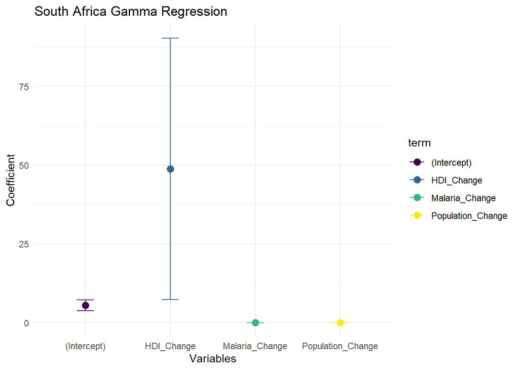

```r
  ### Visualization of Gamma Regression Coefficients
ZAF_gamma_results <- tidy(ZAF_gamma_model)
ggplot(ZAF_gamma_results, aes(x = term, y = estimate, color = term)) +
  geom_point(size = 3) +
  geom_errorbar(aes(ymin = estimate - std.error, ymax = estimate + std.error), width = 0.2) +
  scale_color_viridis_d(option = "viridis") +
  labs(title = "South Africa Gamma Regression",
       x = "Variables", y = "Coefficient") +
  theme_minimal()
```

```r
  ## Interpret the results within the framework of the push-pull theory
ZAF_gamma_results %>%
  mutate(
    interpretation = case_when(
      term == "Malaria_Change" & estimate < 0 ~ "Malaria as a weak push factor",
      term == "Population_Change" & estimate > 0 ~ "Population increase as a significant pull factor",
      term == "HDI_Change" & estimate > 0 ~ "HDI as a potential pull factor",
      T ~ "No significant impact"
    )
  ) %>%
  select(term, estimate, p.value, interpretation) %>%
  print()
```

```
## # A tibble: 4 × 4
##   term                 estimate p.value interpretation
##   <chr>                   <dbl>   <dbl> <chr>
## 1 (Intercept)        5.47       0.00361 No significant impact
## 2 Malaria_Change    -0.00000159 0.940   Malaria as a weak push factor
## 3 Population_Change  0.00000115 0.0742  Population increase as a significant pu…
## 4 HDI_Change        48.8        0.248   HDI as a potential pull factor
```

```r
  ## Zambia Model Analysis
glimpse(ZMB_migration_flows_and)
```

```
## Rows: 3,964
## Columns: 19
## $ NODEI             <dbl> 201, 202, 203, 204, 205, 206, 207, 208, 209, 210, 30…
## $ NODEJ             <dbl> 101, 101, 101, 101, 101, 101, 101, 101, 101, 101, 10…
## $ LONFR             <dbl> 27.78018, 27.69583, 27.91583, 28.25840, 28.38552, 27…
## $ LATFR             <dbl> -12.343630, -12.486254, -12.741161, -12.789234, -13.…
## $ LONTO             <dbl> 28.03562, 28.03562, 28.03562, 28.03562, 28.03562, 28…
## $ LATTO             <dbl> -14.83439, -14.83439, -14.83439, -14.83439, -14.8343…
## $ PrdMIG            <dbl> 457.8132, 698.1624, 508.1001, 1208.1467, 839.9981, 5…
## $ Province_From     <chr> "Copperbelt", "Copperbelt", "Copperbelt", "Copperbel…
## $ Province_To       <chr> "Central", "Central", "Central", "Central", "Central…
## $ geometry          <LINESTRING [°]> LINESTRING (27.78018 -12.34..., LINESTRIN…
## $ HDI2005           <dbl> 0.545, 0.545, 0.545, 0.545, 0.545, 0.545, 0.545, 0.5…
## $ HDI2010           <dbl> 0.601, 0.601, 0.601, 0.601, 0.601, 0.601, 0.601, 0.6…
## $ Malaria2005       <int> 686307, 686307, 686307, 686307, 686307, 686307, 6863…
## $ Malaria2010       <int> 3380, 3380, 3380, 3380, 3380, 3380, 3380, 3380, 3380…
## $ Pop2005           <int> 1820443, 1820443, 1820443, 1820443, 1820443, 1820443…
## $ Pop2010           <int> 1972317, 1972317, 1972317, 1972317, 1972317, 1972317…
## $ Population_Change <int> 151874, 151874, 151874, 151874, 151874, 151874, 1518…
## $ Malaria_Change    <int> -682927, -682927, -682927, -682927, -682927, -682927…
## $ HDI_Change        <dbl> 0.056, 0.056, 0.056, 0.056, 0.056, 0.056, 0.056, 0.0…
```

```r
ZMB_migration_flows_and <- ZMB_migration_flows_and %>%
  filter(!is.na(PrdMIG), !is.na(Malaria_Change), !is.na(Population_Change), !is.na(HDI_Change))
summary(ZMB_migration_flows_and$PrdMIG)
```

```
##      Min.   1st Qu.    Median      Mean   3rd Qu.      Max.
##     9.124    50.456    77.045   160.697   151.871 10276.356
```

```r
  ## Gamma regression model
ZMB_gamma_model <- glm(PrdMIG ~ Malaria_Change + Population_Change + HDI_Change,
                       family = Gamma(link = "log"),
                       data = ZMB_migration_flows_and)
summary(ZMB_gamma_model)
```

```
##
## Call:
## glm(formula = PrdMIG ~ Malaria_Change + Population_Change + HDI_Change,
##     family = Gamma(link = "log"), data = ZMB_migration_flows_and)
##
## Coefficients:
##                     Estimate Std. Error t value Pr(>|t|)
## (Intercept)        6.116e+00  4.238e-01  14.433  < 2e-16 ***
## Malaria_Change     8.729e-07  2.776e-07   3.145  0.00168 **
## Population_Change  1.616e-06  2.237e-07   7.224 6.04e-13 ***
## HDI_Change        -1.447e+01  6.256e+00  -2.313  0.02078 *
## ---
## Signif. codes:  0 '***' 0.001 '**' 0.01 '*' 0.05 '.' 0.1 ' ' 1
##
## (Dispersion parameter for Gamma family taken to be 3.442461)
##
##     Null deviance: 4405.6  on 3963  degrees of freedom
## Residual deviance: 4153.5  on 3960  degrees of freedom
## AIC: 47981
##
## Number of Fisher Scoring iterations: 6
```

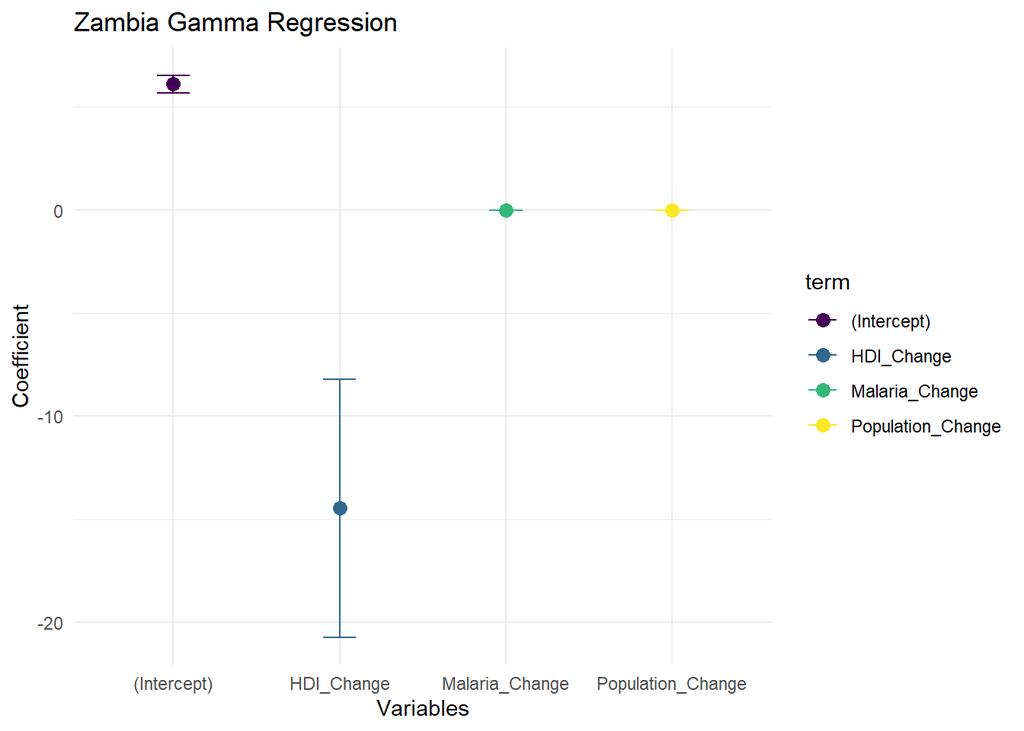

```r
  ### Visualization of Gamma Regression Coefficients
ZMB_gamma_results <- tidy(ZMB_gamma_model)
ggplot(ZMB_gamma_results, aes(x = term, y = estimate, color = term)) +
  geom_point(size = 3) +
  geom_errorbar(aes(ymin = estimate - std.error, ymax = estimate + std.error), width = 0.2) +
  scale_color_viridis_d(option = "viridis") +
  labs(title = "Zambia Gamma Regression",
       x = "Variables", y = "Coefficient") +
  theme_minimal()
```

The chart illustrates the direction, confidence intervals, and significance of each variable. The results are consistent with the push-pull theory.

```r
  ## Visualization of Gamma Regression Coefficients
ZMB_gamma_results %>%
  mutate(
    interpretation = case_when(
      term == "Malaria_Change" & estimate < 0 ~ "Malaria as a weak push factor",
      term == "Population_Change" & estimate > 0 ~ "Population increase as a significant pull factor",
      term == "HDI_Change" & estimate > 0 ~ "HDI as a potential pull factor",
      T ~ "No significant impact"
    )
  ) %>%
  select(term, estimate, p.value, interpretation) %>%
  print()
```

```
## # A tibble: 4 × 4
##   term                   estimate  p.value interpretation
##   <chr>                     <dbl>    <dbl> <chr>
## 1 (Intercept)         6.12        4.68e-46 No significant impact
## 2 Malaria_Change      0.000000873 1.68e- 3 No significant impact
## 3 Population_Change   0.00000162  6.04e-13 Population increase as a significant…
## 4 HDI_Change        -14.5         2.08e- 2 No significant impact
```

```r
#7. Compare Results of South Africa and Zambia
  ## Compare provincial centrality rankings for the two countries
combined_centralities <- bind_rows(
  ZAF_centralities %>%
    rename(centrality = ZAF_network_centrality) %>%
    mutate(country = "South Africa"),
  ZMB_centralities %>%
    rename(centrality = ZMB_network_centrality) %>%
    mutate(country = "Zambia")
) %>%
  arrange(desc(centrality))
  ## Create ranking tables
combined_centralities %>%
  kable(caption = "South Africa vs Zambia") %>%
  scroll_box(width = "100%", height = "400px")
```

South Africa vs Zambia

| names | shapeName | w.in.degree | w.out.degree | w.degree | btwnss_weighted | eigen | prank | r_shapeName | r_w.in.degree | r_w.out.degree | r_w.degree | r_btwnss_weighted | r_eigen | r_prank | all_w.in.degree | all_w.out.degree | all_w.degree | all_btwnss_weighted | all_eigen | all_prank | centrality | country |
| --- | --- | --- | --- | --- | --- | --- | --- | --- | --- | --- | --- | --- | --- | --- | --- | --- | --- | --- | --- | --- | --- | --- |
| 504 | Lusaka | 90431.939 | 40019.679 | 130451.618 | 8.3440296 | 1.0000000 | 0.1063536 | NA | NA | NA | NA | NA | NA | NA | 11.412364 | 10.597152 | 11.778765 | 2.2347376 | 0.6931472 | 0.1010695 | 6.136206 | Zambia |
| 7 | Gauteng | 91557.535 | 36697.947 | 128255.482 | 0.0000000 | 1.0000000 | 0.3147632 | Gauteng | 1 | 2 | 1 | 3 | 1 | 1 | 11.424734 | 10.510503 | 11.761787 | 0.0000000 | 0.6931472 | 0.2736565 | 5.777305 | South Africa |
| 101 | Central | 31114.610 | 25913.077 | 57027.687 | 5.5294291 | 0.7104515 | 0.0458809 | NA | NA | NA | NA | NA | NA | NA | 10.345465 | 10.162542 | 10.951310 | 1.8763195 | 0.5367574 | 0.0448595 | 5.652875 | Zambia |
| 204 | Copperbelt | 40163.449 | 17602.537 | 57765.986 | 6.4876840 | 0.4163942 | 0.0464171 | NA | NA | NA | NA | NA | NA | NA | 10.600737 | 9.775855 | 10.964173 | 2.0132595 | 0.3481144 | 0.0453720 | 5.624585 | Zambia |
| 210 | Copperbelt | 38127.767 | 17553.593 | 55681.360 | 5.8111410 | 0.4150241 | 0.0446029 | NA | NA | NA | NA | NA | NA | NA | 10.548724 | 9.773071 | 10.927419 | 1.9185597 | 0.3471466 | 0.0436368 | 5.593093 | Zambia |
| 8 | Mpumalanga | 23611.667 | 39720.862 | 63332.529 | 0.0000000 | 0.7362891 | 0.1381736 | Mpumalanga | 2 | 1 | 2 | 3 | 2 | 2 | 10.069539 | 10.589657 | 11.056170 | 0.0000000 | 0.5517501 | 0.1294249 | 5.399424 | South Africa |
| 307 | Eastern | 19110.918 | 13615.802 | 32726.719 | 4.9836066 | 0.2651645 | 0.0248863 | NA | NA | NA | NA | NA | NA | NA | 9.858067 | 9.519060 | 10.395978 | 1.7890235 | 0.2352021 | 0.0245817 | 5.303652 | Zambia |
| 6 | North West | 16519.851 | 25498.651 | 42018.503 | 0.6931472 | 0.4640675 | 0.0982515 | North West | 5 | 4 | 4 | 2 | 4 | 4 | 9.712379 | 10.146420 | 10.645889 | 0.5265890 | 0.3812185 | 0.0937194 | 5.251036 | South Africa |
| 9 | Limpopo | 17177.457 | 28182.618 | 45360.075 | 0.0000000 | 0.5296434 | 0.1002536 | Limpopo | 4 | 3 | 3 | 3 | 3 | 3 | 9.751411 | 10.246496 | 10.722410 | 0.0000000 | 0.4250346 | 0.0955407 | 5.206815 | South Africa |
| 105 | Central | 11842.820 | 14252.679 | 26095.499 | 4.9052748 | 0.2216139 | 0.0161937 | NA | NA | NA | NA | NA | NA | NA | 9.379561 | 9.564770 | 10.169556 | 1.7758460 | 0.2001728 | 0.0160640 | 5.184329 | Zambia |
| 407 | Luapula | 10789.381 | 13736.708 | 24526.089 | 5.3327188 | 0.1545458 | 0.0154454 | NA | NA | NA | NA | NA | NA | NA | 9.286410 | 9.527900 | 10.107534 | 1.8457297 | 0.1437070 | 0.0153273 | 5.154435 | Zambia |
| 4 | Free State | 17430.701 | 23598.047 | 41028.748 | 0.0000000 | 0.4100467 | 0.0960969 | Free State | 3 | 5 | 5 | 3 | 5 | 5 | 9.766046 | 10.068962 | 10.622053 | 0.0000000 | 0.3436228 | 0.0917556 | 5.148740 | South Africa |
| 605 | Muchinga | 10712.719 | 12888.724 | 23601.442 | 4.7706846 | 0.1345617 | 0.0148921 | NA | NA | NA | NA | NA | NA | NA | 9.279280 | 9.464186 | 10.069105 | 1.7527907 | 0.1262464 | 0.0147823 | 5.117732 | Zambia |
| 5 | KwaZulu-Natal | 16514.217 | 21043.790 | 37558.007 | 0.0000000 | 0.3600254 | 0.0861450 | KwaZulu-Natal | 6 | 6 | 6 | 3 | 6 | 6 | 9.712037 | 9.954408 | 10.533668 | 0.0000000 | 0.3075034 | 0.0826347 | 5.098375 | South Africa |
| 304 | Eastern | 13252.556 | 8889.875 | 22142.430 | 5.3375381 | 0.1272490 | 0.0172584 | NA | NA | NA | NA | NA | NA | NA | 9.492021 | 9.092781 | 10.005296 | 1.8464904 | 0.1197802 | 0.0171112 | 5.095580 | Zambia |
| 106 | Central | 10097.015 | 13317.686 | 23414.701 | 2.1972246 | 0.1534388 | 0.0148912 | NA | NA | NA | NA | NA | NA | NA | 9.220094 | 9.496923 | 10.061162 | 1.1622831 | 0.1427477 | 0.0147814 | 5.016332 | Zambia |
| 403 | Luapula | 10392.371 | 13693.028 | 24085.400 | 1.6094379 | 0.1659768 | 0.0154880 | NA | NA | NA | NA | NA | NA | NA | 9.248924 | 9.524715 | 10.089403 | 0.9591348 | 0.1535592 | 0.0153693 | 4.998517 | Zambia |
| 103 | Central | 13499.773 | 18264.019 | 31763.792 | 0.0000000 | 0.2767629 | 0.0194462 | NA | NA | NA | NA | NA | NA | NA | 9.510502 | 9.812743 | 10.366114 | 0.0000000 | 0.2443279 | 0.0192595 | 4.992158 | Zambia |
| 102 | Central | 13640.966 | 17646.018 | 31286.985 | 0.0000000 | 0.3030517 | 0.0201930 | NA | NA | NA | NA | NA | NA | NA | 9.520906 | 9.778322 | 10.350989 | 0.0000000 | 0.2647089 | 0.0199918 | 4.989153 | Zambia |
| 502 | Lusaka | 15173.653 | 16157.033 | 31330.686 | 0.0000000 | 0.2346705 | 0.0190449 | NA | NA | NA | NA | NA | NA | NA | 9.627382 | 9.690173 | 10.352385 | 0.0000000 | 0.2108042 | 0.0188659 | 4.983268 | Zambia |
| 907 | Southern | 12225.590 | 18171.337 | 30396.926 | 0.0000000 | 0.3976822 | 0.0187274 | NA | NA | NA | NA | NA | NA | NA | 9.411368 | 9.807656 | 10.322130 | 0.0000000 | 0.3348153 | 0.0185542 | 4.982420 | Zambia |
| 209 | Copperbelt | 18549.656 | 12532.377 | 31082.034 | 0.0000000 | 0.2159230 | 0.0223081 | NA | NA | NA | NA | NA | NA | NA | 9.828261 | 9.436151 | 10.344417 | 0.0000000 | 0.1955034 | 0.0220629 | 4.971066 | Zambia |
| 703 | Northern | 8524.443 | 10069.144 | 18593.588 | 3.9318256 | 0.1051608 | 0.0120454 | NA | NA | NA | NA | NA | NA | NA | 9.050810 | 9.217330 | 9.830626 | 1.5957092 | 0.0999909 | 0.0119734 | 4.967740 | Zambia |
| 2 | Eastern Cape | 12449.247 | 14650.136 | 27099.383 | 0.0000000 | 0.2188905 | 0.0670178 | Eastern Cape | 7 | 7 | 7 | 3 | 7 | 7 | 9.429496 | 9.592273 | 10.207303 | 0.0000000 | 0.1979411 | 0.0648676 | 4.915313 | South Africa |
| 202 | Copperbelt | 15427.731 | 11781.436 | 27209.166 | 0.0000000 | 0.1888690 | 0.0187733 | NA | NA | NA | NA | NA | NA | NA | 9.643987 | 9.374365 | 10.211346 | 0.0000000 | 0.1730025 | 0.0185992 | 4.903550 | Zambia |
| 704 | Northern | 7896.327 | 9742.405 | 17638.733 | 2.7080502 | 0.1044734 | 0.0113586 | NA | NA | NA | NA | NA | NA | NA | 8.974280 | 9.184346 | 9.777909 | 1.3105062 | 0.0993686 | 0.0112946 | 4.892951 | Zambia |
| 1 | Western Cape | 12362.320 | 13363.022 | 25725.342 | 0.0000000 | 0.2173890 | 0.0666872 | Western Cape | 8 | 8 | 8 | 3 | 8 | 8 | 9.422489 | 9.500321 | 10.155271 | 0.0000000 | 0.1967084 | 0.0645578 | 4.889891 | South Africa |
| 807 | North-Western | 9402.339 | 12800.352 | 22202.691 | 0.6931472 | 0.1585559 | 0.0141145 | NA | NA | NA | NA | NA | NA | NA | 9.148820 | 9.457306 | 10.008014 | 0.5265890 | 0.1471743 | 0.0140158 | 4.883653 | Zambia |
| 104 | Central | 10702.646 | 14931.819 | 25634.465 | 0.0000000 | 0.2217079 | 0.0161974 | NA | NA | NA | NA | NA | NA | NA | 9.278340 | 9.611317 | 10.151732 | 0.0000000 | 0.2002498 | 0.0160676 | 4.876284 | Zambia |
| 602 | Muchinga | 7542.188 | 8863.427 | 16405.615 | 3.1780538 | 0.0866368 | 0.0109339 | NA | NA | NA | NA | NA | NA | NA | 8.928400 | 9.089802 | 9.705440 | 1.4298455 | 0.0830874 | 0.0108746 | 4.874575 | Zambia |

[output cut: 51 more lines]

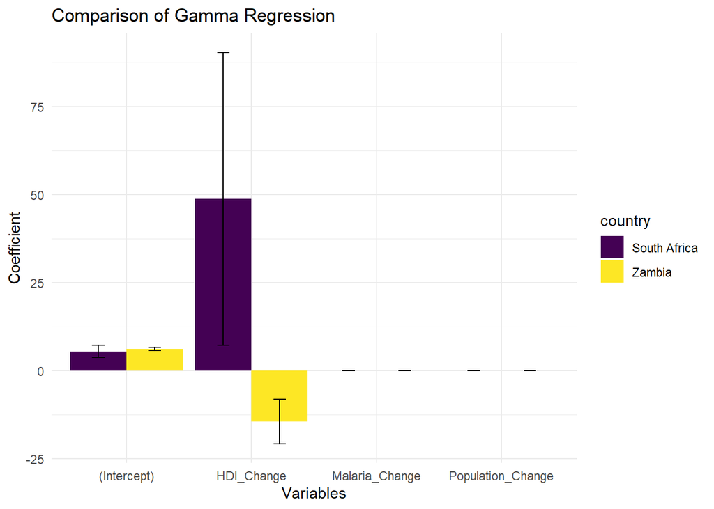

```r
  ## Compare regression model results for South Africa and Zambia
comparison_results <- bind_rows(
  ZAF_gamma_results %>% mutate(country = "South Africa"),
  ZMB_gamma_results %>% mutate(country = "Zambia")
)
  ## Create comparison charts
ggplot(comparison_results, aes(x = term, y = estimate, fill = country)) +
  geom_bar(stat = "identity", position = "dodge") +
  geom_errorbar(aes(ymin = estimate - std.error, ymax = estimate + std.error),
                position = position_dodge(0.9), width = 0.2) +
  scale_fill_viridis_d(option = "D") +
  labs(title = "Comparison of Gamma Regression",
       x = "Variables", y = "Coefficient") +
  theme_minimal()
```

8. Conclusion

Through spatial network analysis of migration flow data in South Africa and Zambia, this study reveals the centrality of provinces in both countries, their role in migration flows and their relationship with changes in population, malaria incidence and HDI.

8.1.Migration network structure South Africa exhibits a highly concentrated migration pattern, with Gauteng serving as a core hub connecting other major migration flows. The overall migration network shows a significant hierarchical structure, which is consistent with the stronger level of economic development and urbanization in South Africa. Zambia shows a more balanced network structure, and the centrality ranking shows that Zambia is not a monocentric structure, and migration flows are more evenly distributed among multiple provinces.

8.3.Simple correlations and regression models Correlation analysis provides an initial connection between migration flows and key variables, but it is difficult to capture complex interactions between variables. Further regression models such as Gamma regression are used to make up for this deficiency. The results show that demographic change is a key driver of migration flows in both countries, while the impact of health and development indicators is more significant in Zambia.

8.4 Comparison and Enlightenment Migration network characteristics and drivers in South Africa and Zambia reflect their different socio-economic backgrounds: Migration in South Africa is concentrated in the core provinces of the economy, showing a stronger central-centric development. In Zambia, the intensity of migration between provinces is relatively balanced, but the development between provinces is stepped and different. Health and social development indicators have a greater impact on migration and mobility, indicating the influence of the allocation of resources and health resources on migration trends.

8.5 Importance of research The study uses migration networks and regression models to investigate migration patterns and migration motivations in sub-Saharan Africa. It looks at how three factors affect migration. Migration in South Africa is concentrated in specific areas. Economic opportunities and urban infrastructure play an important role in shaping migration flows. Provinces like Gauteng have their own gravitational pull that attracts a lot of population movement. This points to the need for better allocation of resources to avoid regional imbalances. In Zambia, the pattern of migration flows is more fragmented. Health problems such as malaria and weak infrastructure are important factors, as economic development is weak and poor environments can increase the incidence of malaria, so health security is an important reason to move people from areas with a high burden of malaria. This highlights the need for better medical services and stronger regional medical systems to balance migration and development in the process of urban development. This research will lead to a better understanding of how health and economic factors interact with movement within regions. They are fundamental to understanding migration in sub-Saharan Africa. Improved health systems and increased regional equity will help manage migration and reduce the burden of crises in the social, economic and health sectors. This information is a valuable guide not only for Africa, but also for other regions facing similar challenges.(Naudé, Rossouw, and Krugell 2009)

9.Limitations and deficiencies

Due to the long time from 2005 to 2010, insufficient data samples, complex cleaning process, and insufficient accuracy of simple correlation detection, it is necessary to constantly adjust the coordinates of search data for matching analysis. I can’t say that the assessment I submitted was perfect. In this research, I still have a lot of ideas to solve, but I still learn a lot: sometimes the results do not meet expectations, Not necessarily bad results, because I didn’t give up, I still thought about how to do better, because I kept trying to solve these “troubles”, I became more and more aware of how to use R language, how to better explore my problems, and I believe that I will conduct persistent spiritual research in the future, celebrating persistence! Praise learning!

10. References

[1]World Health Organization. (2015). World malaria report 2015. Geneva: World Health Organization. Retrieved from https://www.who.int/malaria/publications/world-malaria-report-2015/en/

[2]Maharaj R, Raman J, Morris N, Moonasar D, Durrheim DN, Seocharan I, Kruger P, Shandukani B, Kleinschmidt I. Epidemiology of malaria in South Africa: from control to elimination. S Afr Med J. 2013 Aug 29;103(10 Pt 2):779-83. doi: 10.7196/samj.7441. PMID: 24079633.

[3]Zhao Ziyu, Yang Ran, Wei Ye, Pang Ruiqiu, Wang Shijun. Quantitative Estimation and Spatial Heterogeneity of the Regression Coefficient of the Population Flow Gravity Model in China[J]. SCIENTIA GEOGRAPHICA SINICA, 2018, 38(9): 1439-1448 https://doi.org/10.13249/j.cnki.sgs.2018.09.006

[4]Alkire, Sabina, Dimensions of Human Development (2002). World Development, Volume 30, Issue 2, February 2002, pp. 181–205 , Available at SSRN: https://ssrn.com/abstract=2118655

[5]Khosa, E., Kuonza, L. R., Kruger, P., & Maimela, E. (2013). Towards the elimination of malaria in South Africa: a review of surveillance data in Mutale Municipality, Limpopo Province, 2005 to 2010. Malaria journal, 12, 7. https://doi.org/10.1186/1475-2875-12-7

[6]Sikaala, C.H., Dlamini, B., Lungu, A. et al. Malaria elimination and the need for intensive inter-country cooperation: a critical evaluation of regional technical co-operation in Southern Africa. Malar J 23, 62 (2024). https://doi.org/10.1186/s12936-024-04891-5

[7]Coetzer, R. H., & Adeola, A. M. (2020). Assessing the Correlation between Malaria Case Mortality Rates and Access to Health Facilities in the Malaria Region of Vhembe District, South Africa. Journal of environmental and public health, 2020, 8973739. https://doi.org/10.1155/2020/8973739

[8]Andersson, L., Siegel, M. (2020). The Impact of Migration on Development in Developing Countries: A Review of the Empirical Literature. In: Rayp, G., Ruyssen, I., Marchand, K. (eds) Regional Integration and Migration Governance in the Global South. United Nations University Series on Regionalism, vol 20. Springer, Cham. https://doi.org/10.1007/978-3-030-43942-2_6

[9]Francesco Castelli, Drivers of migration: why do people move?, Journal of Travel Medicine, Volume 25, Issue 1, 2018, tay040, https://doi.org/10.1093/jtm/tay040

[10]Soto Nishimura, A., Czaika, M. Exploring Migration Determinants: a Meta-Analysis of Migration Drivers and Estimates. Int. Migration & Integration 25, 621–643 (2024). https://doi.org/10.1007/s12134-023-01091-z

[11]Black, R., Bellagamba, A., Botta, E. et al. Migration drivers and migration choice: interrogating responses to migration and development interventions in West Africa. CMS 10, 10 (2022). https://doi.org/10.1186/s40878-022-00283-3

[12]de Haas, H. A theory of migration: the aspirations-capabilities framework. CMS 9, 8 (2021). https://doi.org/10.1186/s40878-020-00210-4

[13]Steketee, R. W., Sipilanyambe, N., Chimumbwa, J., Banda, J. J., Mohamed, A., Miller, J., Basu, S., Miti, S. K., & Campbell, C. C. (2008). National malaria control and scaling up for impact: the Zambia experience through 2006. The American journal of tropical medicine and hygiene, 79(1), 45–52.

[14]Tsegay, S. M. (2023). International Migration: Definition, Causes and Effects. Genealogy, 7(3), 61. https://doi.org/10.3390/genealogy7030061

[15]Francesco Castelli, Drivers of migration: why do people move?, Journal of Travel Medicine, Volume 25, Issue 1, 2018, tay040, https://doi.org/10.1093/jtm/tay040

Coetzer, Ryno Harm, and Abiodun Morakinyo Adeola. n.d. “Assessing the Correlation Between Malaria Case Mortality Rates and Access to Health Facilities in the Malaria Region of Vhembe District, South Africa.” *Journal of Environmental and Public Health* 2020 (1): 8973739. https://doi.org/10.1155/2020/8973739.

Maharaj, R, J Raman, N Morris, D Moonasar, DN Durrheim, I Seocharan, P Kruger, B Shandukani, and I Kleinschmidt. 2013. “Epidemiology of Malaria in South Africa: From Control to Elimination.” *South African Medical Journal* 103 (10 Pt 2): 779–83. https://doi.org/10.7196/samj.7441.

Naudé, Wim, Stephanie Rossouw, and Waldo Krugell. 2009. “The Non-Monetary Quality of City Life in South Africa.” *Habitat International* 33 (4): 319–26. https://doi.org/10.1016/j.habitatint.2008.08.004.

Opsahl, Tore, Filip Agneessens, and John Skvoretz. 2010. “Node Centrality in Weighted Networks: Generalizing Degree and Shortest Paths.” *Social Networks* 32 (3): 245–51. https://doi.org/10.1016/j.socnet.2010.03.006.

Zhao, Ziyu, Ran Yang, Ye Wei, Ruiqiu Pang, and Shijun Wang. 2018. “Quantitative Estimation and Spatial Heterogeneity of the Regression Coefficient of the Population Flow Gravity Model in China.” *SCIENTIA GEOGRAPHICA SINICA* 38 (9): 1439–48. https://doi.org/10.13249/j.cnki.sgs.2018.09.006.